# Assignment 5: Part 1

*How to do it?*:

- Open the Rmarkdown file of this assignment (link) in Rstudio.
- Right under each **question**, insert a code chunk (you can use the hotkey `Ctrl + Alt + I` to add a code chunk) and code the solution for the question.
- `Knit` the rmarkdown file (hotkey: `Ctrl + Alt + K`) to export an html.
- Publish the html file to your Githiub Page.

*Submission*: Submit the link on Github of the assignment to Canvas.

**The data:**

This assignment works with the Adult Census Data that can be downloaded at [this link.](https://bryantstats.github.io/math421/data/adult_census_missing.csv)

**Questions**

1. Use `read_csv` to import the data. Show the number of NAs for each columns.

```r
library(tidyverse)
df <- read_csv('https://bryantstats.github.io/math421/data/adult_census_missing.csv')
na_count <- colSums(is.na(df))
print(na_count)
```

```
##            age      workclass         fnlwgt      education  education.num
##             30             34              0             15              0
## marital.status     occupation   relationship           race            sex
##             26             35              0              0             24
##   capital.gain   capital.loss hours.per.week native.country         income
##              8              0              0             15              0
```

2. Using function `aggr` the VIM package to plot the number of NAs for each column.

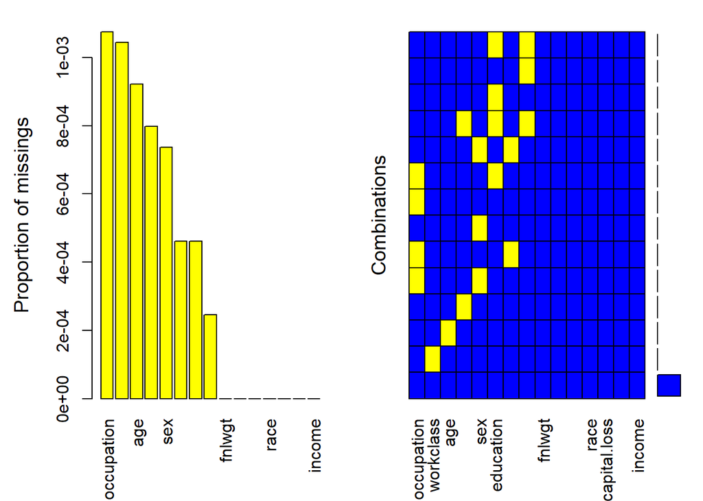

```
##
##  Variables sorted by number of missings:
##        Variable        Count
##      occupation 0.0010749056
##       workclass 0.0010441940
##             age 0.0009213476
##  marital.status 0.0007985013
##             sex 0.0007370781
##       education 0.0004606738
##  native.country 0.0004606738
##    capital.gain 0.0002456927
##          fnlwgt 0.0000000000
##   education.num 0.0000000000
##    relationship 0.0000000000
##            race 0.0000000000
##    capital.loss 0.0000000000
##  hours.per.week 0.0000000000
##          income 0.0000000000
```

```r
library(VIM)
aggr(df, col = c("blue", "yellow"), number = TRUE, sortVars = TRUE)
```

3. Find other forms of missing values. Hint: You can use the `table` function to check if there are suspicious categories (Unknown, for example) in a variable. What all other forms of missing values shown in the data.

```r
colSums(df == 'Missing', na.rm = TRUE)
```

```
##            age      workclass         fnlwgt      education  education.num
##              0              0              0              0              0
## marital.status     occupation   relationship           race            sex
##              0              0              0              0              0
##   capital.gain   capital.loss hours.per.week native.country         income
##              0              0              0              0              0
```

4. Replace all the forms of missing values found to NA

```r
df <- replace(df, df == 'Unknown' |
                  df == 'Missing' |
                  df == 'Not Available', NA)
```

5. Replot the number of NAs for each column.

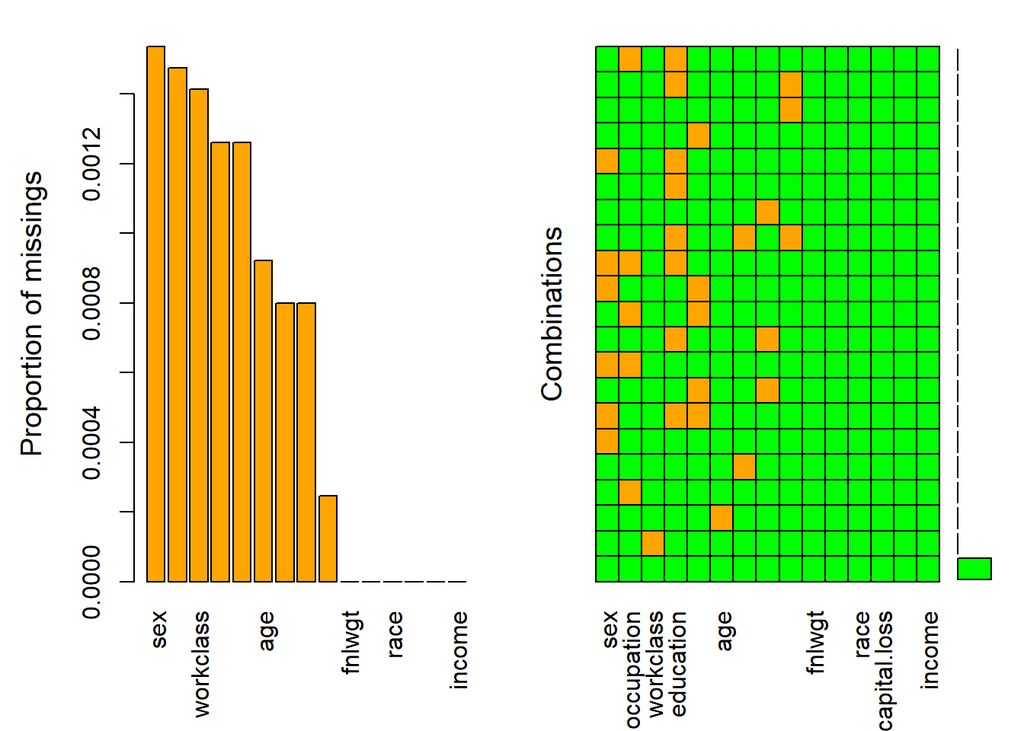

```
##
##  Variables sorted by number of missings:
##        Variable        Count
##             sex 0.0015355794
##      occupation 0.0014741562
##       workclass 0.0014127330
##       education 0.0012591751
##  native.country 0.0012591751
##             age 0.0009213476
##  marital.status 0.0007985013
##    relationship 0.0007985013
##    capital.gain 0.0002456927
##          fnlwgt 0.0000000000
##   education.num 0.0000000000
##            race 0.0000000000
##    capital.loss 0.0000000000
##  hours.per.week 0.0000000000
##          income 0.0000000000
```

```r
aggr(df, col = c("green", "orange"), numbers = TRUE, sortVars = TRUE)
```

```r
df2 = drop_na(df)
```

7. Approach 2 to handle NAs: Fill all the NAs with the previous or next value. (Hint: Using `fill` function). Save the dataset after filling as a different data. The original data is unchanged (still have NAs).

```r
df3 = df %>% fill(age, sex, .direction = 'updown')
```

8. Approach 3 to handle NAs: For numeric variable, replace the NAs by the median. For categorical variables, replace the NAs to the majority.

```r
df4 = median_age <- median(df$age, na.rm=TRUE)
df$age <- replace_na(df$age, df4)
df5 = majority_sex <- names(which.max(table(df$sex)))
df$sex <- replace_na(df$sex, majority_sex)
```